# Bootstrapping Tutrial: Fst from Evans et al 2016

# Fst data

## Load Fst into vector

```r
Fstperloc <- c(0.8589462,0.4133128,0.6851604,0.7366967,0.7925415,0.7161766,0.4683899,0.8355689)
```

## Mean Fst

```r
Fst.mean <- mean(Fstperloc)

Fst.mean
```

```
## [1] 0.6883491
```

## Distribution of Fst values

- 2 Fst values lower than the rest
- Non-normality is a good reason to use boostrapping

### Histogram base R

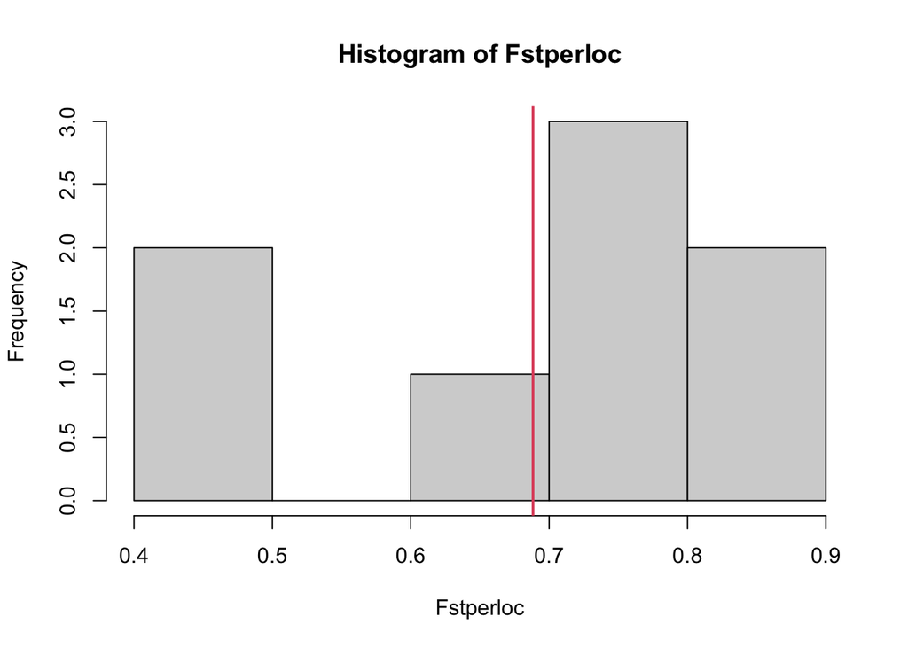

```r
#histogram of Fst
hist(Fstperloc)

#vertical line for mean
abline(v =Fst.mean, col = 2, lwd = 2 )
```

### Boxplot base R

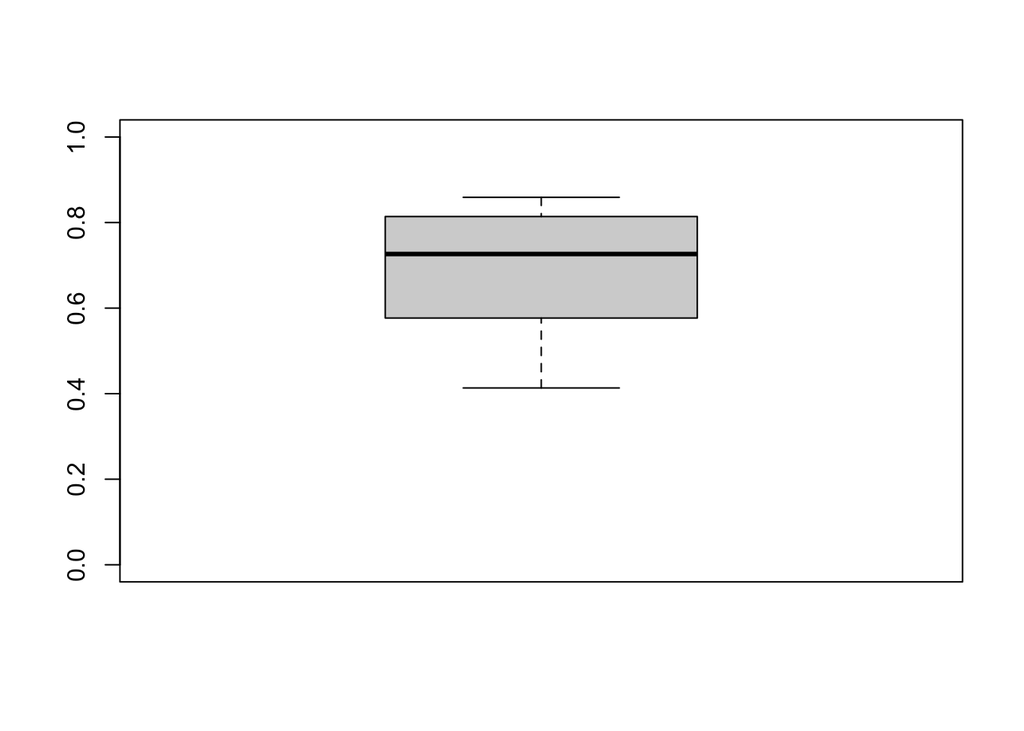

```r
#boxplot
boxplot(Fstperloc,
        ylim = c(0,1))
```

### Boxplot ggplot

Just the boxplot

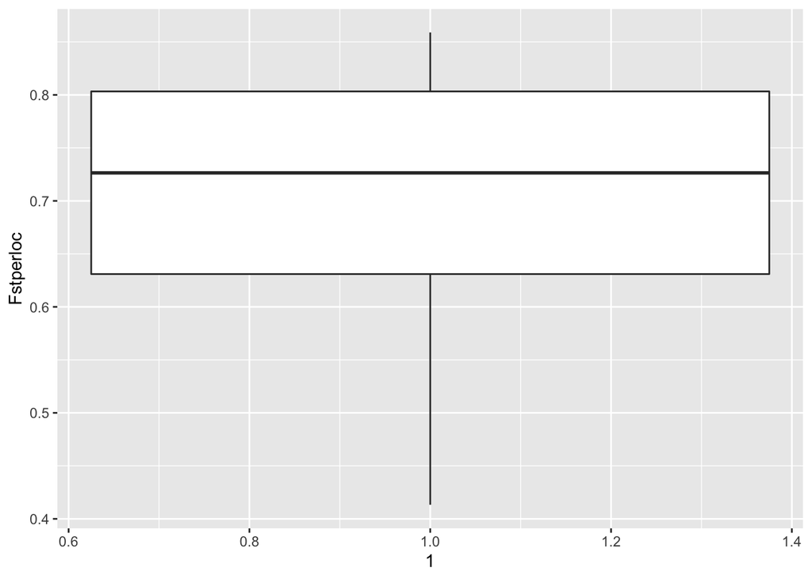

```r
library(ggplot2)

qplot(y = Fstperloc,
      x = 1,
      geom = "boxplot")
```

Boxplot w/ raw data overlayed

- Set 2 “geoms” via “geom = c(”boxplot“,”point")

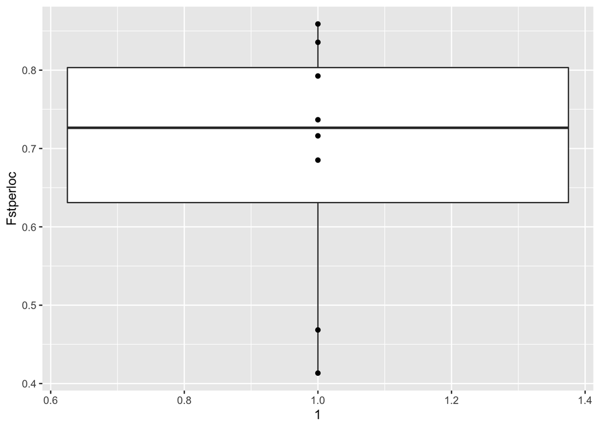

```r
library(ggplot2)

qplot(y = Fstperloc,
      x = 1,
      geom = c("boxplot",
               "point"))
```

# Boostrapping Fst

Boostrapping with boot requires

- Defining a function for the desired summary statistic that is used by the boot() function
  - Want the mean and its confidence intervals
  - A tricky part about boot() is that you have to write a full R function
  - This requires a fair bit code for somethings as simple as the mean
- Extracting the desired confidence interval with boot.ci()

Load the package

```r
#load package
library(boot)
```

## Define function for the mean

- Function synatax takes a particualr form in R
- Here is the R code define a bran new function mean.fun() function that will take 2 arguements
  - dat: our raw data
  - idx: an index of resampled data
- The original data has 8 Fst values
- What boot() does is generate 8 random index (idx) values from from the set c(1,2,3,4,5,6,7,8)
  - Sampling is with replacement
- “dat[idx]” calls up those index values
  - Note, there can be duplicate index values b/c of does sampling w/replacement
- The mean.fun() takes the mean of the data matching those index values
- This is repeatd many many times to build a sampling distribution

### The function mean.fun()

```r
mean.fun <- function(dat, idx) {mean(dat[idx], na.rm=TRUE)}
```

We can test the function

```r
# normal R mean function
mean(Fstperloc)
```

```
## [1] 0.6883491
```

```r
#mean.fun()
mean.fun(Fstperloc, idx = c(1:8))
```

```
## [1] 0.6883491
```

```r
#An arbitay set of idx values
mean.fun(Fstperloc, idx = c(1,1,2,4,5,2,8,7))
```

```
## [1] 0.6722144
```

R has function for generating random numbers. We can generate numbers from a uniform distribution from 1 to 8 like this using runif() for “random uniform”

```r
runif(n = 8,min = 1, max = 8)
```

```
## [1] 1.777656 5.378644 7.287548 2.119946 1.762177 3.101710 6.331893 7.183686
```

We can make these whole numbers by rounding them

```r
round(runif(n = 8,min = 1, max = 8),0)
```

```
## [1] 3 3 6 6 4 2 5 3
```

## Running boot

boot() takes 3 arguments

- The vector of raw data, Fstperloc
- mean.fun, the function for the summary statistica
- The number of replicates R

### Run the function

Run boot()

```r
bootfst = boot(Fstperloc, mean.fun, R=1000)
```

The raw output of boot() isn’t very intersting; it just gives you the original mean

```r
bootfst
```

```
##
## ORDINARY NONPARAMETRIC BOOTSTRAP
##
##
## Call:
## boot(data = Fstperloc, statistic = mean.fun, R = 1000)
##
##
## Bootstrap Statistics :
##      original       bias    std. error
## t1* 0.6883491 -0.002258647  0.05405571
```

boot.ci() extracts the confidence interval

```r
boot.ci(bootfst, type=c("norm"))
```

```
## BOOTSTRAP CONFIDENCE INTERVAL CALCULATIONS
## Based on 1000 bootstrap replicates
##
## CALL :
## boot.ci(boot.out = bootfst, type = c("norm"))
##
## Intervals :
## Level      Normal
## 95%   ( 0.5847,  0.7966 )
## Calculations and Intervals on Original Scale
```

There are numerous types of boostrap confidence itnrvals: “norm”,“basic”, “stud”, “perc”, “bca”. You can get multiples like this

```r
boot.ci(bootfst, type=c("norm",
                        "basic",
                        "perc",
                        "bca"))
```

```
## BOOTSTRAP CONFIDENCE INTERVAL CALCULATIONS
## Based on 1000 bootstrap replicates
##
## CALL :
## boot.ci(boot.out = bootfst, type = c("norm", "basic", "perc",
##     "bca"))
##
## Intervals :
## Level      Normal              Basic
## 95%   ( 0.5847,  0.7966 )   ( 0.5922,  0.8070 )
##
## Level     Percentile            BCa
## 95%   ( 0.5697,  0.7845 )   ( 0.5488,  0.7722 )
## Calculations and Intervals on Original Scale
```

# Compare Fst to Qst

Make a draframe with Fst info and Qst

- All values reported in text

```r
Fst.vs.Qst <- data.frame(Statistic = c("Fst","Qst"),
                   Mean    = c(0.6883491, 1.0),
                   ci.lo   = c(0.556,     0.175),
                   ci.hi   = c(0.772,     1.0))
```

## Plot with ggplot

I do a little trick here to plot the raw data next to Fst

### Generate Jittered locations

- I use rnorm to generate random x axis values centered on 1.12.
- Mean Fst and its CI will get plotted at the 1.0 location on the x axis, though it will be labeled w/“Fst”, not 1.0
- This generates jittered points

```r
Fstperloc.2 <- data.frame(Fstperloc = Fstperloc,
                          y = rnorm(length(Fstperloc), 1.12,0.015))
```

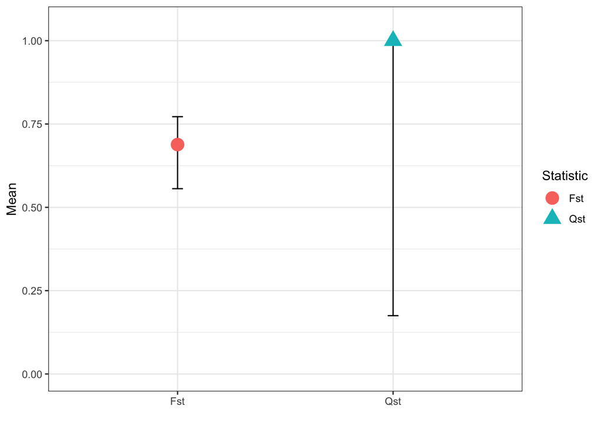

```r
library(ggplot2)
qplot(y = Mean,
      x = Statistic,
      data = Fst.vs.Qst) +
  geom_errorbar(aes(ymin = ci.lo, ymax = ci.hi),
                width = 0.05) +
  geom_point(aes(color = Statistic,
                 shape = Statistic),
             size = 5) +
  theme_bw() +
  ylim(0,1.05) +
  xlab("")
```

#### Plot data w/jittered points

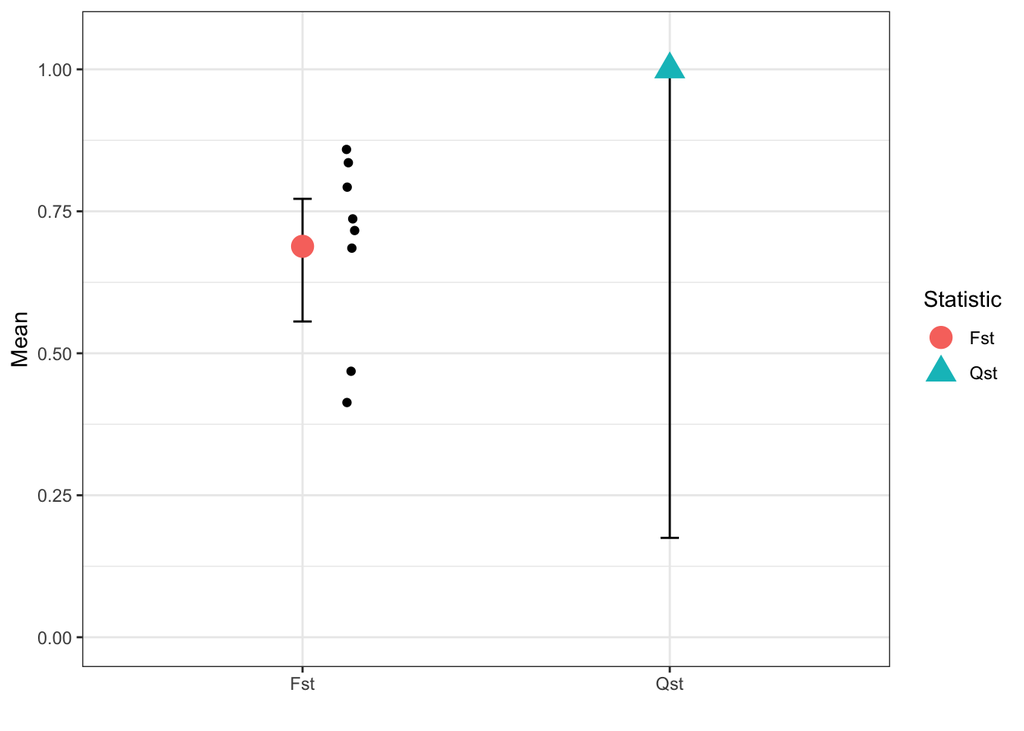

```r
library(ggplot2)
qplot(y = Mean,
      x = Statistic,
      data = Fst.vs.Qst) +
  geom_errorbar(aes(ymin = ci.lo, ymax = ci.hi),
                width = 0.05) +
  geom_point(aes(color = Statistic,
                 shape = Statistic),
             size = 5) +
  theme_bw() +
  geom_point(data = Fstperloc.2,
             aes(y = Fstperloc, x = y)) +
  ylim(0,1.05) +
  xlab("")
```

# From the original text:

Continuing “Nonetheless, each population contained multiple multilocus genotypes (MLGT) (ranging from 0.63 to 2.83 multilocus genotype in offspring per field maternal family across populations), so the low within-population quantitative genetic variation is not solely due to sampling a single selfed lineage. This finding is at odds with our previous work suggesting a rapid evolution of sinigrin concentrations, which should require high levels of intrapopulation genetic variation on which to act (Lankau et al. 2009). However, the levels of intrapopulation genetic variation are likely to vary across the introduced range.”"